# Tugas Praktikum 3

```r
#PACKAGES
#install.packages("dLagM")
#install.packages("dynlm")
#install.packages("MLmetrics")
library(dLagM)
library(dynlm)
library(MLmetrics)
library(lmtest)
library(car)
```

# BAGIAN 1: Data Market Share dan Price

## Impor Data

```r
data <- rio::import("C:\\Users\\najwe\\OneDrive\\Dokumen\\SEMESTER 5\\MPDW\\Tugas\\Tugas Kuliah 2\\data market share price.xlsx")
str(data)
```

```
## 'data.frame':    20 obs. of  3 variables:
##  $ Period      : num  1 2 3 4 5 6 7 8 9 10 ...
##  $ Market share: num  3.63 4.2 3.33 4.54 2.89 4.87 4.9 5.29 6.18 7.2 ...
##  $ Price       : num  0.97 0.95 0.99 0.91 0.98 0.9 0.89 0.86 0.85 0.82 ...
```

```r
data
```

```
##    Period Market share Price
## 1       1         3.63  0.97
## 2       2         4.20  0.95
## 3       3         3.33  0.99
## 4       4         4.54  0.91
## 5       5         2.89  0.98
## 6       6         4.87  0.90
## 7       7         4.90  0.89
## 8       8         5.29  0.86
## 9       9         6.18  0.85
## 10     10         7.20  0.82
## 11     11         7.25  0.79
## 12     12         6.09  0.83
## 13     13         6.80  0.81
## 14     14         8.65  0.77
## 15     15         8.43  0.76
## 16     16         8.29  0.80
## 17     17         7.18  0.83
## 18     18         7.90  0.79
## 19     19         8.45  0.76
## 20     20         8.23  0.78
```

```r
data$Xt <- as.numeric(data$Price)
data$Yt <- as.numeric(data$`Market share`)
```

## Pembagian Data

```r
#SPLIT DATA
train<-data[1:16,]
test<-data[17:20,]
```

```r
#data time series
train.ts<-ts(train)
test.ts<-ts(test)
data.ts<-ts(data)
```

- **distributed lag model** : Variabel Dependen Y dipengaruhi oleh lag dari variabel independen X (Xt-1, Xt-2 , dst)
- **Autoregresive model** : Variabel Dependen Y dipengaruhi oleh lag dirinya sendiri (Yt-1, Yt-2, dst) dan X sekarang (Xt)

## Model Koyck

Model Koyck didasarkan pada asumsi bahwa semakin jauh jarak lag peubah independen dari periode sekarang maka semakin kecil pengaruh peubah lag terhadap peubah dependen.

Koyck mengusulkan suatu metode untuk menduga model dinamis distributed lag dengan mengasumsikan bahwa semua koefisien $\beta$ mempunyai tanda sama.

Model kyock merupakan jenis paling umum dari model infinite distributed lag dan juga dikenal sebagai geometric lag

$$y_t=a(1-\lambda)+\beta_0X_t+\beta_1Z_t+\lambda Y_{t-1}+V_t$$

dengan
$$V_t=u_t-\lambda
u_{t-1}$$

### Pemodelan

```r
#MODEL KOYCK
model.koyck <- koyckDlm(x = train$Xt, y = train$Yt)
summary(model.koyck)
```

```
##
## Call:
## "Y ~ (Intercept) + Y.1 + X.t"
##
## Residuals:
##      Min       1Q   Median       3Q      Max
## -1.08831 -0.33583  0.03809  0.32369  1.08271
##
## Coefficients:
##             Estimate Std. Error t value Pr(>|t|)
## (Intercept)  14.1547    13.9055   1.018    0.329
## Y.1           0.4356     0.4547   0.958    0.357
## X.t         -12.4022    13.2392  -0.937    0.367
##
## Residual standard error: 0.6214 on 12 degrees of freedom
## Multiple R-Squared: 0.9013,  Adjusted R-squared: 0.8848
## Wald test: 42.97 on 2 and 12 DF,  p-value: 3.383e-06
##
## Diagnostic tests:
## NULL
##
##                             alpha      beta       phi
## Geometric coefficients:  25.08051 -12.40215 0.4356312
```

```r
AIC(model.koyck)
```

```
## [1] 32.94998
```

```r
BIC(model.koyck)
```

```
## [1] 35.78218
```

Berdasarkan hasil uji-t, seluruh peubah pada model Koyck ($X_t$, $Y_{t-1}$, maupun intersep) memiliki nilai p-value > 0.05, sehingga secara individual tidak ada peubah yang berpengaruh signifikan terhadap $Y_t$ pada taraf nyata 5%. Meski demikian, model secara simultan signifikan (uji Wald, p-value = 3.383e-06) dengan $R^2 = 0.9013$. Model keseluruhan yang terbentuk adalah:

$$\hat{Y_t}=14.1547-12.4022X_t+0.4356Y_{t-1}$$

dengan bentuk jangka panjang (geometric form): $\alpha=25.0805$, $\beta=-12.4022$, $\lambda(\phi)=0.4356$.

### Peramalan dan Akurasi

Berikut adalah hasil peramalan y untuk 4 periode kedepan menggunakan model koyck

```r
fore.koyck <- forecast(model = model.koyck, x=test$Xt, h=4)
fore.koyck
```

```
## $forecasts
## [1] 7.472253 7.612103 8.045091 7.985671
##
## $call
## forecast.koyckDlm(model = model.koyck, x = test$Xt, h = 4)
##
## attr(,"class")
## [1] "forecast.koyckDlm" "dLagM"
```

```r
mape.koyck <- MAPE(fore.koyck$forecasts, test$Yt)
mape.koyck #data test
```

```
## [1] 0.03868805
```

```r
#akurasi data training
GoF(model.koyck)
```

```
##              n       MAE         MPE       MAPE      sMAPE      MASE       MSE
## model.koyck 15 0.4501447 -0.01928604 0.08947964 0.08570486 0.5178329 0.3089595
##                 MRAE     GMRAE
## model.koyck 1.706297 0.6506363
```

Hasil peramalan model Koyck untuk 4 periode ke depan (periode 17–20) menghasilkan nilai $\hat{Y}$ = 7.4723, 7.6121, 8.0451, dan 7.9857, yang relatif mendekati nilai aktual pada data uji (7.18, 7.90, 8.45, 8.23). Nilai MAPE data uji sebesar 3.87%, lebih kecil dibandingkan MAPE data latih sebesar 8.95%. Karena MAPE data uji tidak lebih besar dari data latih, model Koyck tidak menunjukkan gejala overfitting dan mampu melakukan generalisasi dengan cukup baik pada data baru.

## Model Ad-Hoc

### Pemodelan (Lag=2)

```r
model.dlm <- dlm(x = train$Xt,y = train$Yt , q = 2)        #q=jumlah lag

summary(model.dlm)
```

```
##
## Call:
## lm(formula = model.formula, data = design)
##
## Residuals:
##      Min       1Q   Median       3Q      Max
## -0.74815 -0.25820  0.02732  0.28252  0.63650
##
## Coefficients:
##             Estimate Std. Error t value Pr(>|t|)
## (Intercept)   27.690      1.699  16.293 1.58e-08 ***
## x.t          -20.911      4.094  -5.107 0.000459 ***
## x.1           -1.384      3.484  -0.397 0.699626
## x.2           -2.930      4.279  -0.685 0.509026
## ---
## Signif. codes:  0 '***' 0.001 '**' 0.01 '*' 0.05 '.' 0.1 ' ' 1
##
## Residual standard error: 0.4876 on 10 degrees of freedom
## Multiple R-squared:  0.9456, Adjusted R-squared:  0.9293
## F-statistic: 57.99 on 3 and 10 DF,  p-value: 1.255e-06
##
## AIC and BIC values for the model:
##        AIC      BIC
## 1 24.90966 28.10495
```

```r
AIC(model.dlm)
```

```
## [1] 24.90966
```

```r
BIC(model.dlm)
```

```
## [1] 28.10495
```

Dari hasil di atas, terlihat bahwa intersep dan $X_t$ memiliki nilai p-value < 0.05, sehingga keduanya berpengaruh signifikan terhadap $Y$, sedangkan $X_{t-1}$ (p = 0.6996) dan $X_{t-2}$ (p = 0.5090) tidak signifikan. Model keseluruhannya adalah:

$$\hat{Y_t}=27.6900-20.9110X_t-1.3840X_{t-1}-2.9300X_{t-2}$$

### Peramalan dan Akurasi (Lag=2)

Berikut merupakan hasil peramalan $y$ untuk 4 periode kedepan

```r
fore.dlm <- forecast(model = model.dlm, x=test$Xt, h=4)
fore.dlm
```

```
## $forecasts
## [1] 7.000140 7.677840 8.272596 8.013110
##
## $call
## forecast.dlm(model = model.dlm, x = test$Xt, h = 4)
##
## attr(,"class")
## [1] "forecast.dlm" "dLagM"
```

```r
mape.dlm <- MAPE(fore.dlm$forecasts, test$Yt)
mape.dlm
```

```
## [1] 0.02512994
```

```r
#akurasi data training
GoF(model.dlm)
```

```
##            n       MAE          MPE       MAPE      sMAPE      MASE       MSE
## model.dlm 14 0.3271441 -0.001862647 0.05567658 0.05583942 0.3763605 0.1698395
##               MRAE     GMRAE
## model.dlm 1.266737 0.3698695
```

Hasil peramalan model DLM dengan lag=2 untuk periode 17–20 adalah $\hat{Y}$ = 7.0001, 7.6778, 8.2726, dan 8.0131. Nilai MAPE data uji sebesar 2.51%, lebih kecil dari MAPE data latih (5.57%), sehingga model ini juga tidak overfitting dan justru memiliki akurasi peramalan yang lebih baik dibandingkan model Koyck.

### *Lag* Optimum

```r
#penentuan lag optimum
finiteDLMauto(formula = Yt ~ Xt,
              data = data.frame(train), q.min = 1, q.max = 10,
              model.type = "dlm", error.type = "AIC", trace = TRUE)
```

```
##    q - k    MASE      AIC      BIC   GMRAE    MBRAE R.Adj.Sq  Ljung-Box
## 7      7 0.00000     -Inf     -Inf 0.00000  0.00000      NaN        NaN
## 8      8 0.00000     -Inf     -Inf 0.00000  0.00000      NaN        NaN
## 9      9 0.00000     -Inf     -Inf 0.00000  0.00000      NaN        NaN
## 10    10 0.00000     -Inf     -Inf 0.00000  0.00000      NaN        NaN
## 6      6 0.13287  1.98713  4.71040 0.18229 -1.24656  0.96533 0.01068512
## 3      3 0.34462 22.56595 25.95564 0.52942 -0.28497  0.92805 0.36111348
## 4      4 0.40523 24.69501 28.08935 0.62345 -0.23409  0.90356 0.39796261
## 2      2 0.37636 24.90966 28.10495 0.36987  0.48249  0.92933 0.60057711
## 1      1 0.41045 25.13707 27.96927 0.40480  0.34718  0.93158 0.34041201
## 5      5 0.45914 25.46443 28.64759 0.51799 -0.39806  0.80070 0.75246966
```

Berdasarkan output tersebut, lag optimum didapatkan ketika lag=6. Selanjutnya dilakukan pemodelan untuk lag=6

```r
#model dlm dengan lag optimum
model.dlm2 <- dlm(x = train$Xt,y = train$Yt , q = 6)
summary(model.dlm2)
```

```
##
## Call:
## lm(formula = model.formula, data = design)
##
## Residuals:
##        1        2        3        4        5        6        7        8
## -0.03176  0.09878 -0.04964 -0.06891  0.09801 -0.01274 -0.11718  0.14837
##        9       10
## -0.19442  0.12948
##
## Coefficients:
##               Estimate Std. Error t value Pr(>|t|)
## (Intercept)  39.610423   2.445120  16.200  0.00379 **
## x.t         -44.999765   5.805344  -7.751  0.01624 *
## x.1          -0.003881   4.972069  -0.001  0.99945
## x.2          -0.754941   3.126247  -0.241  0.83168
## x.3           2.613010   3.441267   0.759  0.52695
## x.4          20.866178   4.944108   4.220  0.05182 .
## x.5          -0.225961   3.105220  -0.073  0.94861
## x.6         -17.222920   3.651689  -4.716  0.04213 *
## ---
## Signif. codes:  0 '***' 0.001 '**' 0.01 '*' 0.05 '.' 0.1 ' ' 1
##
## Residual standard error: 0.243 on 2 degrees of freedom
## Multiple R-squared:  0.9923, Adjusted R-squared:  0.9653
## F-statistic:  36.8 on 7 and 2 DF,  p-value: 0.02671
##
## AIC and BIC values for the model:
##        AIC    BIC
## 1 1.987134 4.7104
```

```r
AIC(model.dlm2)
```

```
## [1] 1.987134
```

```r
BIC(model.dlm2)
```

```
## [1] 4.7104
```

Pada taraf nyata 5%, peubah yang berpengaruh signifikan adalah intersep, $X_t$, dan $X_{t-6}$, sedangkan $X_{t-4}$ hanya signifikan pada taraf 10% dan peubah lag lainnya ($X_{t-1}, X_{t-2}, X_{t-3}, X_{t-5}$) tidak signifikan. Model keseluruhannya adalah:

$$\hat{Y_t}=39.6104-44.9998X_t-0.0039X_{t-1}-0.7549X_{t-2}+2.6130X_{t-3}+20.8662X_{t-4}-0.2260X_{t-5}-17.2229X_{t-6}$$

Adapun hasil peramalan 4 periode kedepan menggunakan model tersebut adalah sebagai berikut

```r
#peramalan dan akurasi (Lag=optimum)
fore.dlm2 <- forecast(model = model.dlm2, x=test$Xt, h=4)

#akurasi data test
mape.dlm2<- MAPE(fore.dlm2$forecasts, test$Yt)
mape.dlm2
```

```
## [1] 0.07898388
```

```r
#akurasi data training
GoF(model.dlm2)
```

```
##             n        MAE           MPE       MAPE      sMAPE      MASE
## model.dlm2 10 0.09492917 -0.0001507547 0.01314349 0.01314632 0.1328713
##                   MSE      MRAE     GMRAE
## model.dlm2 0.01180581 0.4890752 0.1822903
```

Nilai MAPE data latih model DLM lag=6 sangat kecil (1.31%), tetapi MAPE data uji jauh lebih besar (7.90%). Selisih yang cukup jauh antara MAPE latih dan MAPE uji ini mengindikasikan model mengalami **overfitting**,model terlalu menyesuaikan diri terhadap data latih (yang jumlah observasinya kecil dan sisa derajat bebasnya hanya 2) sehingga performanya menurun saat digunakan pada data baru. Hal ini menjadi salah satu pertimbangan mengapa DLM lag=6 tidak dipilih sebagai model terbaik meskipun memiliki AIC terendah pada data latih.

## Model Autoregressive

### Pemodelan

```r
model.ardl <- ardlDlm(x = train$Xt, y = train$Yt, p = 1 , q = 1)
summary(model.ardl)
```

```
##
## Time series regression with "ts" data:
## Start = 2, End = 16
##
## Call:
## dynlm(formula = as.formula(model.text), data = data, start = 1)
##
## Residuals:
##     Min      1Q  Median      3Q     Max
## -0.5826 -0.2578 -0.1355  0.2923  0.6791
##
## Coefficients:
##             Estimate Std. Error t value Pr(>|t|)
## (Intercept)  16.0526     8.5567   1.876   0.0874 .
## X.t         -22.3164     3.0888  -7.225  1.7e-05 ***
## X.1           7.6883     8.0695   0.953   0.3612
## Y.1           0.4233     0.3292   1.286   0.2249
## ---
## Signif. codes:  0 '***' 0.001 '**' 0.01 '*' 0.05 '.' 0.1 ' ' 1
##
## Residual standard error: 0.4664 on 11 degrees of freedom
## Multiple R-squared:  0.949,  Adjusted R-squared:  0.9351
## F-statistic: 68.25 on 3 and 11 DF,  p-value: 2.147e-07
```

```r
AIC(model.ardl)
```

```
## [1] 25.03625
```

```r
BIC(model.ardl)
```

```
## [1] 28.57651
```

```r
model.ardl <- ardlDlm(formula = Yt ~ Xt,
                         data = train,p = 1 , q = 1)
summary(model.ardl)
```

```
##
## Time series regression with "ts" data:
## Start = 2, End = 16
##
## Call:
## dynlm(formula = as.formula(model.text), data = data)
##
## Residuals:
##     Min      1Q  Median      3Q     Max
## -0.5826 -0.2578 -0.1355  0.2923  0.6791
##
## Coefficients:
##             Estimate Std. Error t value Pr(>|t|)
## (Intercept)  16.0526     8.5567   1.876   0.0874 .
## Xt.t        -22.3164     3.0888  -7.225  1.7e-05 ***
## Xt.1          7.6883     8.0695   0.953   0.3612
## Yt.1          0.4233     0.3292   1.286   0.2249
## ---
## Signif. codes:  0 '***' 0.001 '**' 0.01 '*' 0.05 '.' 0.1 ' ' 1
##
## Residual standard error: 0.4664 on 11 degrees of freedom
## Multiple R-squared:  0.949,  Adjusted R-squared:  0.9351
## F-statistic: 68.25 on 3 and 11 DF,  p-value: 2.147e-07
```

```r
AIC(model.ardl)
```

```
## [1] 25.03625
```

```r
BIC(model.ardl)
```

```
## [1] 28.57651
```

Hasil uji-t menunjukkan hanya $X_t$ yang berpengaruh signifikan terhadap $Y_t$ (p = 1.7e-05), sedangkan intersep (p = 0.0874) hanya signifikan pada taraf 10%, dan $X_{t-1}$ maupun $Y_{t-1}$ tidak signifikan (p > 0.05). Model keseluruhannya adalah sebagai berikut:

$$\hat{Y_t}=16.0526-22.3164X_t+7.6883X_{t-1}+0.4233Y_{t-1}$$

### Peramalan dan Akurasi

```r
fore.ardl <- forecast(model = model.ardl, x=test$Xt, h=4)
fore.ardl
```

```
## $forecasts
## [1] 7.189733 7.847306 8.487607 8.081662
##
## $call
## forecast.ardlDlm(model = model.ardl, x = test$Xt, h = 4)
##
## attr(,"class")
## [1] "forecast.ardlDlm" "dLagM"
```

Data di atas merupakan hasil peramalan untuk 4 periode ke depan menggunakan Model Autoregressive dengan $p=1$ dan $q=1$.

```r
mape.ardl <- MAPE(fore.ardl$forecasts, test$Yt)
mape.ardl
```

```
## [1] 0.007625056
```

```r
#akurasi data training
GoF(model.ardl)
```

```
##             n       MAE          MPE       MAPE      sMAPE      MASE       MSE
## model.ardl 15 0.3576038 -0.003051323 0.06189325 0.06186574 0.4113766 0.1595401
##                MRAE     GMRAE
## model.ardl 2.079258 0.6117331
```

Nilai MAPE data uji (0,76%) justru lebih kecil dibandingkan MAPE data latih (6,19%). Ini menunjukkan model Autoregressive tidak mengalami overfitting, bahkan mampu melakukan generalisasi dengan sangat baik pada data baru.

### *Lag* Optimum

```r
#penentuan lag optimum
model.ardl.opt <- ardlBoundOrders(data = data.frame(train), ic = "AIC",
                                   formula = Yt ~ Xt,
                                   max.p = 4, max.q = 4)
model.ardl.opt
```

```
## $p
##   Xt
## 1  2
##
## $q
## [1] 4
##
## $Stat.table
##          q = 1    q = 2    q = 3    q = 4
## p = 1 25.57510 25.82247 27.89719 28.56704
## p = 2 25.08513 20.03778 21.29951 13.46085
## p = 3 21.61406 21.61406 20.63787       NA
## p = 4 24.58363       NA       NA       NA
##
## $min.Stat
## [1] 13.46085
```

```r
# Mencari posisi nilai terkecil pada matriks (mengabaikan NA)
tbl <- model.ardl.opt$Stat.table
idx <- which(tbl == min(tbl, na.rm = TRUE), arr.ind = TRUE)

p_opt <- idx[1, "row"] # Hasil: 2
q_opt <- idx[1, "col"] # Hasil: 4

# Tambahkan baris ini untuk mengambil nilai AIC minimum
aic_min <- min(tbl, na.rm = TRUE)

# Menampilkan hasil
data.frame("p_optimum" = p_opt, "q_optimum" = q_opt, "AIC" = aic_min)
```

```
##   p_optimum q_optimum      AIC
## 1         2         4 13.46085
```

Berdasarkan pencarian otomatis menggunakan `ardlBoundOrders()`, diperoleh AIC terendah sebesar 13.46085, yang dicapai pada kombinasi p = 2 (lag untuk peubah X/Price) dan q = 4 (orde autoregressive untuk Y/Market share). Artinya, model ARDL optimum untuk data ini adalah ARDL(2, 4), sebagaimana yang kemudian dibangun ulang pada tahap berikutnya.

```r
#Pemodelan dengan Lag optimum
model.ardl.opt.fit <- ardlDlm(formula = Yt ~ Xt, data = train,
                               p = p_opt, q = q_opt)
summary(model.ardl.opt.fit)
```

```
##
## Time series regression with "ts" data:
## Start = 5, End = 16
##
## Call:
## dynlm(formula = as.formula(model.text), data = data)
##
## Residuals:
##        5        6        7        8        9       10       11       12
##  0.03895  0.10356 -0.12393 -0.04745  0.29025  0.25017 -0.39354 -0.50847
##       13       14       15       16
## -0.55327  0.45739 -0.19227  0.67859
##
## Coefficients:
##              Estimate Std. Error t value Pr(>|t|)
## (Intercept)  16.77384   28.98251   0.579    0.594
## Xt.t        -20.47024   12.68693  -1.613    0.182
## Xt.1         14.06637   22.12871   0.636    0.560
## Xt.2         -9.09453   29.60882  -0.307    0.774
## Yt.1          0.55578    0.82024   0.678    0.535
## Yt.2         -0.26249    1.01403  -0.259    0.809
## Yt.3          0.20168    0.29375   0.687    0.530
## Yt.4         -0.04269    0.27664  -0.154    0.885
##
## Residual standard error: 0.633 on 4 degrees of freedom
## Multiple R-squared:  0.9508, Adjusted R-squared:  0.8646
## F-statistic: 11.04 on 7 and 4 DF,  p-value: 0.01756
```

```r
AIC(model.ardl.opt.fit)
```

```
## [1] 27.89719
```

```r
BIC(model.ardl.opt.fit)
```

```
## [1] 32.26135
```

```r
#Peramalan dan Akurasi
fore.ardl.opt <- forecast(model = model.ardl.opt.fit, x = test$Xt, h = 4)
fore.ardl.opt
```

```
## $forecasts
## [1] 7.973645 8.588252 8.772650 8.188360
##
## $call
## forecast.ardlDlm(model = model.ardl.opt.fit, x = test$Xt, h = 4)
##
## attr(,"class")
## [1] "forecast.ardlDlm" "dLagM"
```

```r
mape.ardl.opt <- MAPE(fore.ardl.opt$forecasts, test$Yt)
mape.ardl.opt
```

```
## [1] 0.06022473
```

```r
#akurasi data latih
GoF(model.ardl.opt.fit)
```

```
##                     n       MAE          MPE       MAPE      sMAPE      MASE
## model.ardl.opt.fit 12 0.3031546 -0.002084651 0.04394977 0.04381804 0.3951067
##                          MSE     MRAE     GMRAE
## model.ardl.opt.fit 0.1335725 1.812104 0.6273235
```

## Perbandingan Model

Membuat tabel ringkas akurasi model berdasarkan nilai MAPE (Mean Absolute Percentage Error).

```r
akurasi <- matrix(c(mape.koyck, mape.dlm, mape.dlm2, mape.ardl, mape.ardl.opt))
row.names(akurasi) <- c("Koyck", "DLM 1", "DLM 2",
                         "Autoregressive", "Autoregressive Optimum")
colnames(akurasi) <- c("MAPE")
akurasi
```

```
##                               MAPE
## Koyck                  0.038688050
## DLM 1                  0.025129937
## DLM 2                  0.078983884
## Autoregressive         0.007625056
## Autoregressive Optimum 0.060224728
```

### Plot

Untuk membandingkan hasil peramalan dari berbagai model (Koyck, DLM 1, DLM 2, ARDL, dan ARDL Optimum) dengan data aktual, dibuat grafik garis. Visualisasi ini membantu melihat seberapa dekat hasil ramalan tiap model dengan nilai aktual.

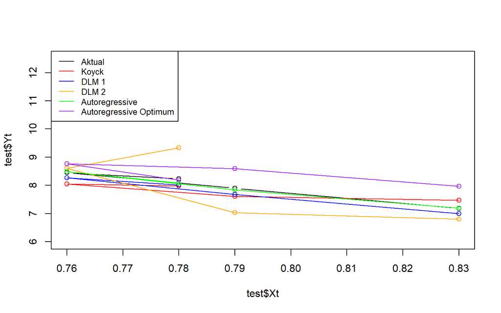

```r
#plot perbandingan
par(mfrow = c(1, 1))  # atur layout grafik tunggal

# plot data aktual
plot(test$Xt, test$Yt, type = "b", col = "black", ylim = c(6, 12.5))

# tambahkan garis ramalan dari masing-masing model
points(test$Xt, fore.koyck$forecasts, col = "red");    lines(test$Xt, fore.koyck$forecasts, col = "red")
points(test$Xt, fore.dlm$forecasts, col = "blue");     lines(test$Xt, fore.dlm$forecasts, col = "blue")
points(test$Xt, fore.dlm2$forecasts, col = "orange");  lines(test$Xt, fore.dlm2$forecasts, col = "orange")
points(test$Xt, fore.ardl$forecasts, col = "green");   lines(test$Xt, fore.ardl$forecasts, col = "green")
points(test$Xt, fore.ardl.opt$forecasts, col = "purple"); lines(test$Xt, fore.ardl.opt$forecasts, col = "purple")

# legenda model
legend("topleft",
       c("Aktual", "Koyck", "DLM 1", "DLM 2", "Autoregressive", "Autoregressive Optimum"),
       lty = 1, col = c("black", "red", "blue", "orange", "green", "purple"), cex = 0.8)
```

# BAGIAN 2: Data Sales dan Advertising

## Impor Data

```r
data2 <- rio::import("C:\\Users\\najwe\\OneDrive\\Dokumen\\SEMESTER 5\\MPDW\\Tugas\\Tugas Kuliah 2\\data sales advertising.xlsx")
str(data2)
```

```
## 'data.frame':    40 obs. of  3 variables:
##  $ Year       : num  1975 1976 1977 1978 1979 ...
##  $ Sales      : num  11.7 12 12.3 12.8 13.1 13.6 13.9 14.4 14.7 15.3 ...
##  $ Advertising: num  9.4 9.6 10 10.4 10.8 10.9 11.7 12.2 12.5 12.9 ...
```

```r
data2
```

```
##    Year Sales Advertising
## 1  1975  11.7         9.4
## 2  1976  12.0         9.6
## 3  1977  12.3        10.0
## 4  1978  12.8        10.4
## 5  1979  13.1        10.8
## 6  1980  13.6        10.9
## 7  1981  13.9        11.7
## 8  1982  14.4        12.2
## 9  1983  14.7        12.5
## 10 1984  15.3        12.9
## 11 1985  15.5        13.0
## 12 1986  15.8        13.2
## 13 1987  16.1        13.8
## 14 1988  16.6        14.2
```

[output cut: 26 more lines]

```r
data2$Xt <- as.numeric(data2$Advertising)
data2$Yt <- as.numeric(data2$Sales)
```

## Pembagian Data

```r
#SPLIT DATA
train2 <- data2[1:32, ]
test2 <- data2[33:40, ]
```

```r
#data time series
train2.ts <- ts(train2)
test2.ts <- ts(test2)
data2.ts <- ts(data2)
```

- **distributed lag model** : Variabel Dependen Y dipengaruhi oleh lag dari variabel independen X (Xt-1, Xt-2 , dst)
- **Autoregresive model** : Variabel Dependen Y dipengaruhi oleh lag dirinya sendiri (Yt-1, Yt-2, dst) dan X sekarang (Xt)

## Model Autoregressive

### Pemodelan

```r
model.ardl2 <- ardlDlm(x = train2$Xt, y = train2$Yt, p = 1, q = 1)
summary(model.ardl2)
```

```
##
## Time series regression with "ts" data:
## Start = 2, End = 32
##
## Call:
## dynlm(formula = as.formula(model.text), data = data, start = 1)
##
## Residuals:
##      Min       1Q   Median       3Q      Max
## -0.42212 -0.13934  0.00585  0.09313  0.33270
##
## Coefficients:
##             Estimate Std. Error t value Pr(>|t|)
## (Intercept)  1.30304    0.47500   2.743   0.0107 *
## X.t          0.30844    0.15564   1.982   0.0578 .
## X.1         -0.20644    0.17382  -1.188   0.2453
## Y.1          0.83951    0.09995   8.399  5.2e-09 ***
## ---
## Signif. codes:  0 '***' 0.001 '**' 0.01 '*' 0.05 '.' 0.1 ' ' 1
##
## Residual standard error: 0.1791 on 27 degrees of freedom
## Multiple R-squared:  0.9943, Adjusted R-squared:  0.9937
## F-statistic:  1575 on 3 and 27 DF,  p-value: < 2.2e-16
```

```r
AIC(model.ardl2)
```

```
## [1] -12.93737
```

```r
BIC(model.ardl2)
```

```
## [1] -5.767436
```

```r
model.ardl2 <- ardlDlm(formula = Yt ~ Xt, data = train2, p = 1, q = 1)
summary(model.ardl2)
```

```
##
## Time series regression with "ts" data:
## Start = 2, End = 32
##
## Call:
## dynlm(formula = as.formula(model.text), data = data)
##
## Residuals:
##      Min       1Q   Median       3Q      Max
## -0.42212 -0.13934  0.00585  0.09313  0.33270
##
## Coefficients:
##             Estimate Std. Error t value Pr(>|t|)
## (Intercept)  1.30304    0.47500   2.743   0.0107 *
## Xt.t         0.30844    0.15564   1.982   0.0578 .
## Xt.1        -0.20644    0.17382  -1.188   0.2453
## Yt.1         0.83951    0.09995   8.399  5.2e-09 ***
## ---
## Signif. codes:  0 '***' 0.001 '**' 0.01 '*' 0.05 '.' 0.1 ' ' 1
##
## Residual standard error: 0.1791 on 27 degrees of freedom
## Multiple R-squared:  0.9943, Adjusted R-squared:  0.9937
## F-statistic:  1575 on 3 and 27 DF,  p-value: < 2.2e-16
```

```r
AIC(model.ardl2)
```

```
## [1] -12.93737
```

```r
BIC(model.ardl2)
```

```
## [1] -5.767436
```

Hasil uji-t menunjukkan intersep (p=0.0107) dan $Y_{t-1}$ (p=5.2e-09) berpengaruh signifikan terhadap $Y_t$ pada taraf 5%. $X_t$ hanya signifikan pada taraf 10% (p=0.0578), sedangkan $X_{t-1}$ tidak signifikan (p=0.2453). Model keseluruhannya adalah sebagai berikut:

$$\hat{Y_t}=1.3030+0.3084X_t-0.2064X_{t-1}+0.8395Y_{t-1}$$

### Peramalan dan Akurasi

```r
fore.ardl2 <- forecast(model = model.ardl2, x = test2$Xt, h = 8)
fore.ardl2
```

```
## $forecasts
## [1] 19.52586 19.90030 20.04949 20.26727 20.41900 20.71081 20.98614 21.29912
##
## $call
## forecast.ardlDlm(model = model.ardl2, x = test2$Xt, h = 8)
##
## attr(,"class")
## [1] "forecast.ardlDlm" "dLagM"
```

Data di atas merupakan hasil peramalan untuk 8 periode ke depan menggunakan Model Autoregressive dengan $p=1$ dan $q=1$.

```r
mape.ardl2 <- MAPE(fore.ardl2$forecasts, test2$Yt)
mape.ardl2
```

```
## [1] 0.01905123
```

```r
# Akurasi data training
GoF(model.ardl2)
```

```
##              n       MAE          MPE        MAPE       sMAPE      MASE
## model.ardl2 31 0.1351188 -0.000172352 0.008225628 0.008223183 0.4768899
##                    MSE     MRAE     GMRAE
## model.ardl2 0.02793731 73180231 0.7094915
```

Nilai MAPE data latih (0.82%) dan data uji (1.91%) relatif kecil dan berdekatan, mengindikasikan model tidak overfit maupun underfit dan memiliki akurasi peramalan yang sangat baik.

### *Lag* Optimum

```r
#penentuan lag optimum
model.ardl.opt2 <- ardlBoundOrders(data = data.frame(train2), ic = "AIC",
                                    formula = Yt ~ Xt)
model.ardl.opt2
```

```
## $p
##   Xt
## 1  8
##
## $q
## [1] 9
##
## $Stat.table
##             q = 1      q = 2      q = 3      q = 4      q = 5       q = 6
## p = 1  -13.152246 -10.184497  -8.106966  -6.856816  -3.298772   -4.425921
## p = 2  -11.648161  -9.809908  -7.254672  -5.689361  -2.279843   -2.700293
## p = 3   -7.702995  -7.702995  -9.502040  -7.270320  -3.758204   -2.854285
## p = 4   -9.139679  -7.280046  -7.280046  -5.427058  -1.984810   -1.139921
## p = 5   -6.211749  -4.849111  -5.682300  -5.682300  -5.365467   -4.999131
## p = 6   -4.670978  -3.007143  -4.281505  -2.662497  -2.662497   -3.035021
## p = 7   -4.342225  -2.665394  -2.927914  -1.656976  -3.078078   -3.078078
## p = 8  -11.975552 -13.431277 -13.081889 -11.334003 -10.258984  -21.895501
## p = 9  -19.452272 -19.346500 -20.597028 -41.271543 -54.330899 -114.943873
## p = 10 -10.419318  -8.671152  -7.523531  -7.694296 -21.113413          NA
## p = 11 -10.595273 -12.150924 -10.646178         NA         NA          NA
## p = 12 -34.750246         NA         NA         NA         NA          NA
##                q = 7       q = 8        q = 9     q = 10    q = 11     q = 12
## p = 1    -3.07806648   -4.114779   -2.2165889 -10.329843 -14.66214  -9.640939
## p = 2    -1.51654304   -3.726196   -0.9127438  -9.737938 -12.72374 -18.902512
## p = 3    -1.14100756   -3.753408   -6.3041683  -7.739135 -26.95680         NA
## p = 4     0.58721371   -1.838272   -4.6324700  -5.980978 -27.36296         NA
## p = 5    -1.84390253   -4.123992   -5.4004419  -4.156318        NA         NA
## p = 6    -0.02032614   -2.154186   -3.4195892 -20.281145        NA         NA
## p = 7   -16.58157023  -22.034769  -25.2424452         NA        NA         NA
## p = 8   -21.89550100  -24.010300 -145.6545680         NA        NA         NA
## p = 9  -115.52181739 -115.521817           NA         NA        NA         NA
## p = 10            NA          NA           NA         NA        NA         NA
## p = 11            NA          NA           NA         NA        NA         NA
## p = 12            NA          NA           NA         NA        NA         NA
##        q = 13 q = 14 q = 15
## p = 1      NA     NA     NA
## p = 2      NA     NA     NA
## p = 3      NA     NA     NA
## p = 4      NA     NA     NA
## p = 5      NA     NA     NA
## p = 6      NA     NA     NA
## p = 7      NA     NA     NA
## p = 8      NA     NA     NA
## p = 9      NA     NA     NA
## p = 10     NA     NA     NA
## p = 11     NA     NA     NA
## p = 12     NA     NA     NA
##
## $min.Stat
## [1] -145.6546
```

```r
min_p = c()
for (i in 1:ncol(model.ardl.opt2$Stat.table)) {
  min_p[i] = min(model.ardl.opt2$Stat.table[[i]], na.rm = TRUE) # Tambahkan na.rm = TRUE
}

q_opt2 = which.min(min_p)
p_opt2 = which.min(model.ardl.opt2$Stat.table[[q_opt2]])

data.frame("q_optimum" = q_opt2,
           "p_optimum" = p_opt2,
           "AIC" = min(min_p, na.rm = TRUE))
```

```
##   q_optimum p_optimum       AIC
## 1         9         8 -145.6546
```

AIC minimum sebesar -145.6546 diperoleh pada kombinasi p = 8 (lag Advertising) dan q = 9 (orde autoregressive Sales). Namun, lag q = 9 dan p = 8 tergolong besar dibandingkan 32 observasi data latih sehingga berisiko menyebabkan overfitting dan mengurangi derajat bebas. Oleh karena itu, model ARDL(1,1) yang telah dibangun sebelumnya lebih layak dipilih sebagai model akhir karena memiliki MAPE data uji yang rendah (1,91%) dan tidak menunjukkan gejala overfitting.

```r
#Pemodelan
model.ardl2.opt.fit <- ardlDlm(formula = Yt ~ Xt, data = train2,
                                p = p_opt2, q = q_opt2)
summary(model.ardl2.opt.fit)
```

```
##
## Time series regression with "ts" data:
## Start = 10, End = 32
##
## Call:
## dynlm(formula = as.formula(model.text), data = data)
##
## Residuals:
##        10        11        12        13        14        15        16        17
## -0.080231  0.025295  0.009092  0.081663 -0.030735  0.049268  0.009530 -0.056315
##        18        19        20        21        22        23        24        25
##  0.005658 -0.018195 -0.039601  0.093684 -0.048638  0.019970  0.005082 -0.028632
##        26        27        28        29        30        31        32
## -0.000735 -0.064146  0.135728 -0.078820  0.085323 -0.129838  0.055592
##
## Coefficients:
##             Estimate Std. Error t value Pr(>|t|)
## (Intercept)   1.5118     2.0818   0.726   0.5079
## Xt.t          0.6870     0.2328   2.951   0.0419 *
## Xt.1         -0.5217     0.4278  -1.220   0.2896
## Xt.2          0.4382     0.5013   0.874   0.4314
## Xt.3         -0.2381     0.3175  -0.750   0.4950
## Xt.4         -0.1459     0.2433  -0.600   0.5809
## Xt.5          0.1083     0.2175   0.498   0.6448
## Xt.6         -0.3613     0.2320  -1.557   0.1944
## Xt.7          0.4888     0.3319   1.473   0.2148
## Xt.8         -0.7286     0.2890  -2.521   0.0653 .
## Yt.1          0.8728     0.3243   2.691   0.0546 .
## Yt.2         -0.8203     0.5841  -1.404   0.2329
## Yt.3          0.7876     0.5516   1.428   0.2265
## Yt.4         -0.2495     0.4595  -0.543   0.6160
## Yt.5         -0.1666     0.3847  -0.433   0.6872
## Yt.6          0.5254     0.4137   1.270   0.2729
## Yt.7         -0.8146     0.6236  -1.306   0.2615
## Yt.8          0.8921     0.6432   1.387   0.2377
## Yt.9          0.1244     0.3795   0.328   0.7595
## ---
## Signif. codes:  0 '***' 0.001 '**' 0.01 '*' 0.05 '.' 0.1 ' ' 1
##
## Residual standard error: 0.1506 on 4 degrees of freedom
## Multiple R-squared:  0.9974, Adjusted R-squared:  0.9858
## F-statistic: 85.79 on 18 and 4 DF,  p-value: 0.0002963
```

```r
AIC(model.ardl2.opt.fit)
```

```
## [1] -22.03477
```

```r
BIC(model.ardl2.opt.fit)
```

```
## [1] 0.6751153
```

```r
#Peramalan dan Akurasi
fore.ardl2.opt <- forecast(model = model.ardl2.opt.fit, x = test2$Xt, h = 8)
fore.ardl2.opt
```

```
## $forecasts
## [1] 19.57689 19.62091 19.00873 19.41643 19.64595 19.74726 19.86825 19.97974
##
## $call
## forecast.ardlDlm(model = model.ardl2.opt.fit, x = test2$Xt, h = 8)
##
## attr(,"class")
## [1] "forecast.ardlDlm" "dLagM"
```

```r
mape.ardl2.opt <- MAPE(fore.ardl2.opt$forecasts, test2$Yt)
mape.ardl2.opt
```

```
## [1] 0.02215303
```

```r
#akurasi data latih
GoF(model.ardl2.opt.fit)
```

```
##                      n        MAE           MPE        MAPE       sMAPE
## model.ardl2.opt.fit 23 0.05007699 -1.261432e-05 0.002796022 0.002796283
##                          MASE         MSE     MRAE     GMRAE
## model.ardl2.opt.fit 0.2118642 0.003946047 13014362 0.3724325
```

### Perbandingan Model

```r
akurasi2 <- matrix(c(mape.ardl2, mape.ardl2.opt))
row.names(akurasi2) <- c("Autoregressive ARDL(1,1)", "Autoregressive ARDL(8,9)")
colnames(akurasi2) <- c("MAPE")
akurasi2
```

```
##                                MAPE
## Autoregressive ARDL(1,1) 0.01905123
## Autoregressive ARDL(8,9) 0.02215303
```